# Cyclistic Bike-Share Analysis

## How Does a Bike-Share Navigate Speedy Success?

**Project Title:** Cyclistic Bike-Share Usage Pattern Analysis  
**Author:** Tsuyoshi Aita  
**Date Created:** 2025-06-16  
**Version:** v1.0

## Project Overview

**Objective:** Analyze usage patterns between annual members and casual riders to develop marketing strategies for converting casual riders into annual members.

**Key Stakeholders:**

- Lily Moreno (Director of Marketing)
- Cyclistic Marketing Analytics Team
- Cyclistic Executive Team

**Business Question:** How do annual members and casual riders use Cyclistic bikes differently?

## 1. Import Libraries and Load Data

```python
# Import required libraries
import pandas as pd
import numpy as np
import matplotlib.pyplot as plt
import seaborn as sns
from scipy import stats
import warnings
warnings.filterwarnings('ignore')

# Set plotting style
plt.style.use('default')
sns.set_palette("husl")

# Load datasets
print("Loading datasets...")
df2019 = pd.read_csv('Divvy_Trips_2019_Q1 - Divvy_Trips_2019_Q1.csv')
df2020 = pd.read_csv('Divvy_Trips_2020_Q1 - Divvy_Trips_2020_Q1.csv')

print(f"2019 Data Shape: {df2019.shape}")
print(f"2020 Data Shape: {df2020.shape}")
```

```
Loading datasets...
2019 Data Shape: (365069, 12)
2020 Data Shape: (426887, 13)
```

## 2. Data Exploration and Understanding

```python
# Examine data structure and user types
print("=== 2019 Data Overview ===")
print("User types:", df2019["usertype"].unique())
print("\nData types:")
print(df2019.dtypes)
print("\nFirst 3 rows:")
display(df2019.head(3))

print("\n=== 2020 Data Overview ===")
print("User types:", df2020["member_casual"].unique())
print("\nData types:")
print(df2020.dtypes)
print("\nFirst 3 rows:")
display(df2020.head(3))
```

```
=== 2019 Data Overview ===
User types: ['Subscriber' 'Customer']

Data types:
trip_id                int64
start_time            object
end_time              object
bikeid                 int64
tripduration          object
from_station_id        int64
from_station_name     object
to_station_id          int64
to_station_name       object
usertype              object
gender                object
birthyear            float64
dtype: object

First 3 rows:
```

|  | trip_id | start_time | end_time | bikeid | tripduration | from_station_id | from_station_name | to_station_id | to_station_name | usertype | gender | birthyear |
| --- | --- | --- | --- | --- | --- | --- | --- | --- | --- | --- | --- | --- |
| 0 | 21742443 | 2019-01-01 0:04:37 | 2019-01-01 0:11:07 | 2167 | 390 | 199 | Wabash Ave & Grand Ave | 84 | Milwaukee Ave & Grand Ave | Subscriber | Male | 1989.0 |
| 1 | 21742444 | 2019-01-01 0:08:13 | 2019-01-01 0:15:34 | 4386 | 441 | 44 | State St & Randolph St | 624 | Dearborn St & Van Buren St (*) | Subscriber | Female | 1990.0 |
| 2 | 21742445 | 2019-01-01 0:13:23 | 2019-01-01 0:27:12 | 1524 | 829 | 15 | Racine Ave & 18th St | 644 | Western Ave & Fillmore St (*) | Subscriber | Female | 1994.0 |

```
=== 2020 Data Overview ===
User types: ['member' 'casual']

Data types:
ride_id                object
rideable_type          object
started_at             object
ended_at               object
start_station_name     object
start_station_id        int64
end_station_name       object
end_station_id        float64
start_lat             float64
start_lng             float64
end_lat               float64
end_lng               float64
member_casual          object
dtype: object

First 3 rows:
```

|  | ride_id | rideable_type | started_at | ended_at | start_station_name | start_station_id | end_station_name | end_station_id | start_lat | start_lng | end_lat | end_lng | member_casual |
| --- | --- | --- | --- | --- | --- | --- | --- | --- | --- | --- | --- | --- | --- |
| 0 | EACB19130B0CDA4A | docked_bike | 2020-01-21 20:06:59 | 2020-01-21 20:14:30 | Western Ave & Leland Ave | 239 | Clark St & Leland Ave | 326.0 | 41.9665 | -87.6884 | 41.9671 | -87.6674 | member |
| 1 | 8FED874C809DC021 | docked_bike | 2020-01-30 14:22:39 | 2020-01-30 14:26:22 | Clark St & Montrose Ave | 234 | Southport Ave & Irving Park Rd | 318.0 | 41.9616 | -87.6660 | 41.9542 | -87.6644 | member |
| 2 | 789F3C21E472CA96 | docked_bike | 2020-01-09 19:29:26 | 2020-01-09 19:32:17 | Broadway & Belmont Ave | 296 | Wilton Ave & Belmont Ave | 117.0 | 41.9401 | -87.6455 | 41.9402 | -87.6530 | member |

## 3. Data Processing and Cleaning

```
=== Missing Values Analysis ===
```

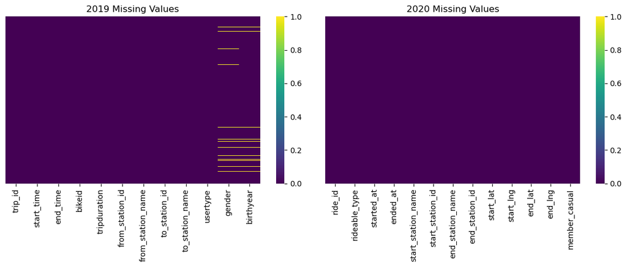

```
2019 Missing values:
trip_id                  0
start_time               0
end_time                 0
bikeid                   0
tripduration             0
from_station_id          0
from_station_name        0
to_station_id            0
to_station_name          0
usertype                 0
gender               19711
birthyear            18023
dtype: int64

2020 Missing values:
ride_id               0
rideable_type         0
started_at            0
ended_at              0
start_station_name    0
start_station_id      0
end_station_name      1
end_station_id        1
start_lat             0
start_lng             0
end_lat               1
end_lng               1
member_casual         0
dtype: int64
```

```python
# Visualize missing values
print("=== Missing Values Analysis ===")
plt.figure(figsize=(12, 5))

plt.subplot(1, 2, 1)
sns.heatmap(df2019.isnull(), cbar=True, yticklabels=False, cmap='viridis')
plt.title('2019 Missing Values')

plt.subplot(1, 2, 2)
sns.heatmap(df2020.isnull(), cbar=True, yticklabels=False, cmap='viridis')
plt.title('2020 Missing Values')

plt.tight_layout()
plt.show()

print("2019 Missing values:")
print(df2019.isnull().sum())
print("\n2020 Missing values:")
print(df2020.isnull().sum())
```

```python
# Clean 2020 data by removing rows with missing values
print("=== Data Cleaning Process ===")
initial_2020_count = len(df2020)
df2020.dropna(inplace=True)
print(f"2020 data: Removed {initial_2020_count - len(df2020)} rows with missing values")
print(f"Remaining 2020 data: {len(df2020)} rows")
```

```
=== Data Cleaning Process ===
2020 data: Removed 1 rows with missing values
Remaining 2020 data: 426886 rows
```

```python
# Standardize column names and remove unnecessary columns
print("=== Column Standardization ===")

# Remove unnecessary columns from 2020 data
df2020 = df2020.drop(['rideable_type', 'start_station_id', 'end_station_id',
                      'start_lat', 'end_lat', 'start_lng', 'end_lng'], axis=1)

# Rename columns for consistency
df2020 = df2020.rename(columns={
    'started_at': 'start_time',
    'ended_at': 'end_time',
    'member_casual': 'usertype',
    'ride_id': 'trip_id'
})

# Remove unnecessary columns from 2019 data
df2019 = df2019.drop(['bikeid', 'tripduration', 'from_station_id',
                      'to_station_id', 'gender', 'birthyear'], axis=1)

# Rename columns for consistency
df2019 = df2019.rename(columns={
    'from_station_name': 'start_station_name',
    'to_station_name': 'end_station_name'
})

print("Column standardization completed")
print("2019 columns:", df2019.columns.tolist())
print("2020 columns:", df2020.columns.tolist())
```

```
=== Column Standardization ===
Column standardization completed
2019 columns: ['trip_id', 'start_time', 'end_time', 'start_station_name', 'end_station_name', 'usertype']
2020 columns: ['trip_id', 'start_time', 'end_time', 'start_station_name', 'end_station_name', 'usertype']
```

```python
# Combine datasets and create derived features
print("=== Data Integration and Feature Engineering ===")

# Combine datasets
df_combined = pd.concat([df2019, df2020], ignore_index=True)
print(f"Combined dataset shape: {df_combined.shape}")

# Convert datetime columns
df_combined['start_time'] = pd.to_datetime(df_combined['start_time'])
df_combined['end_time'] = pd.to_datetime(df_combined['end_time'])

# Create derived features
df_combined['ride_length'] = (df_combined['end_time'] - df_combined['start_time']).dt.total_seconds() / 60.0
df_combined['day_of_week'] = df_combined['start_time'].dt.day_name()
df_combined['month'] = df_combined['start_time'].dt.month
df_combined['start_hour'] = df_combined['start_time'].dt.hour

# Standardize user type labels
df_combined["usertype"] = df_combined["usertype"].replace({
    "Subscriber": "member",
    "Customer": "casual"
})

print("Feature engineering completed")
print("New columns:", ['ride_length', 'day_of_week', 'month', 'start_hour'])
```

```
=== Data Integration and Feature Engineering ===
Combined dataset shape: (791955, 6)
Feature engineering completed
New columns: ['ride_length', 'day_of_week', 'month', 'start_hour']
```

```python
# Data quality checks and outlier removal
print("=== Data Quality Assessment ===")

# Check for duplicates
print(f"Duplicate rows: {df_combined.duplicated().sum()}")

# Check ride_length for anomalies
print(f"\n=== Ride Length Quality Check ===")
print(f"Negative values: {(df_combined['ride_length'] < 0).sum()} trips")
print(f"Zero duration: {(df_combined['ride_length'] == 0).sum()} trips")
print(f"Over 24 hours: {(df_combined['ride_length'] > 1440).sum()} trips")

# Remove anomalous values
initial_count = len(df_combined)
df_combined = df_combined[
    (df_combined['ride_length'] > 0) &
    (df_combined['ride_length'] <= 1440)
]

# Remove test stations
df_combined = df_combined[df_combined['start_station_name'] != 'HQ QR']

print(f"\n=== Final Dataset ===")
print(f"Removed {initial_count - len(df_combined)} anomalous records")
print(f"Final dataset: {len(df_combined)} trips")
print(f"Date range: {df_combined['start_time'].min()} to {df_combined['start_time'].max()}")
```

```
=== Data Quality Assessment ===
Duplicate rows: 0

=== Ride Length Quality Check ===
Negative values: 116 trips
Zero duration: 93 trips
Over 24 hours: 482 trips

=== Final Dataset ===
Removed 4248 anomalous records
Final dataset: 787707 trips
Date range: 2019-01-01 00:04:37 to 2020-03-31 23:51:34
```

## 4. Exploratory Data Analysis (EDA)

```python
# Basic statistics by user type
print("=== User Type Comparison ===")

# User type distribution
user_counts = df_combined['usertype'].value_counts()
user_percentages = df_combined['usertype'].value_counts(normalize=True) * 100

print("Trip counts by user type:")
for usertype, count in user_counts.items():
    percentage = user_percentages[usertype]
    print(f"  {usertype.capitalize()}: {count:,} trips ({percentage:.1f}%)")

# Detailed statistics by user type
print("\n=== Ride Length Statistics by User Type ===")
ride_stats = df_combined.groupby('usertype')['ride_length'].agg([
    'count', 'mean', 'median', 'std', 'min', 'max'
]).round(2)
display(ride_stats)
```

```
=== User Type Comparison ===
Trip counts by user type:
  Member: 720,125 trips (91.4%)
  Casual: 67,582 trips (8.6%)

=== Ride Length Statistics by User Type ===
```

| usertype | count | mean | median | std | min | max |
| --- | --- | --- | --- | --- | --- | --- |
| casual | 67582 | 38.38 | 23.13 | 76.33 | 0.03 | 1435.92 |
| member | 720125 | 11.41 | 8.47 | 21.20 | 0.02 | 1433.07 |

```python
# Statistical significance test
print("=== Statistical Significance Test ===")

member_rides = df_combined[df_combined['usertype'] == 'member']['ride_length']
casual_rides = df_combined[df_combined['usertype'] == 'casual']['ride_length']

# Perform t-test
t_stat, p_value = stats.ttest_ind(casual_rides, member_rides)

print(f"T-statistic: {t_stat:.4f}")
print(f"P-value: {p_value:.2e}")
print(f"Significant difference: {'Yes' if p_value < 0.05 else 'No'} (α=0.05)")
print(f"\nConclusion: Casual riders have {'significantly' if p_value < 0.05 else 'no significantly'} different ride lengths than members")
```

```
=== Statistical Significance Test ===
T-statistic: 222.1151
P-value: 0.00e+00
Significant difference: Yes (α=0.05)

Conclusion: Casual riders have significantly different ride lengths than members
```

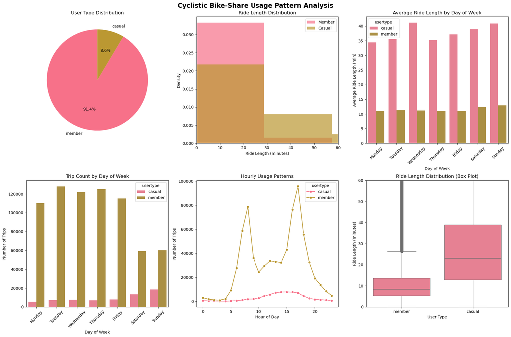

```python
# Comprehensive visualization analysis
fig, axes = plt.subplots(2, 3, figsize=(18, 12))
fig.suptitle('Cyclistic Bike-Share Usage Pattern Analysis', fontsize=16, fontweight='bold')

# 1. User type distribution (pie chart)
user_counts.plot(kind='pie', ax=axes[0,0], autopct='%1.1f%%', startangle=90)
axes[0,0].set_title('User Type Distribution')
axes[0,0].set_ylabel('')

# 2. Ride length distribution by user type
for usertype in ['member', 'casual']:
    data = df_combined[df_combined['usertype'] == usertype]['ride_length']
    axes[0,1].hist(data, bins=50, alpha=0.7, label=usertype.capitalize(), density=True)
axes[0,1].set_title('Ride Length Distribution')
axes[0,1].set_xlabel('Ride Length (minutes)')
axes[0,1].set_ylabel('Density')
axes[0,1].legend()
axes[0,1].set_xlim(0, 60)  # Focus on typical ride lengths

# 3. Average ride length by day of week
weekday_order = ['Monday', 'Tuesday', 'Wednesday', 'Thursday', 'Friday', 'Saturday', 'Sunday']
weekday_avg = df_combined.groupby(['day_of_week', 'usertype'])['ride_length'].mean().reset_index()
sns.barplot(data=weekday_avg, x='day_of_week', y='ride_length', hue='usertype',
           order=weekday_order, ax=axes[0,2])
axes[0,2].set_title('Average Ride Length by Day of Week')
axes[0,2].set_xlabel('Day of Week')
axes[0,2].set_ylabel('Average Ride Length (min)')
axes[0,2].tick_params(axis='x', rotation=45)

# 4. Trip count by day of week
weekday_counts = df_combined.groupby(['day_of_week', 'usertype']).size().reset_index(name='count')
sns.barplot(data=weekday_counts, x='day_of_week', y='count', hue='usertype',
           order=weekday_order, ax=axes[1,0])
axes[1,0].set_title('Trip Count by Day of Week')
axes[1,0].set_xlabel('Day of Week')
axes[1,0].set_ylabel('Number of Trips')
axes[1,0].tick_params(axis='x', rotation=45)

# 5. Hourly usage patterns
hourly_counts = df_combined.groupby(['start_hour', 'usertype']).size().reset_index(name='count')
sns.lineplot(data=hourly_counts, x='start_hour', y='count', hue='usertype',
            marker='o', ax=axes[1,1])
axes[1,1].set_title('Hourly Usage Patterns')
axes[1,1].set_xlabel('Hour of Day')
axes[1,1].set_ylabel('Number of Trips')

# 6. Box plot of ride lengths
sns.boxplot(data=df_combined, x='usertype', y='ride_length', ax=axes[1,2])
axes[1,2].set_title('Ride Length Distribution (Box Plot)')
axes[1,2].set_xlabel('User Type')
axes[1,2].set_ylabel('Ride Length (minutes)')
axes[1,2].set_ylim(0, 60)  # Focus on typical ride lengths

plt.tight_layout()
plt.show()
```

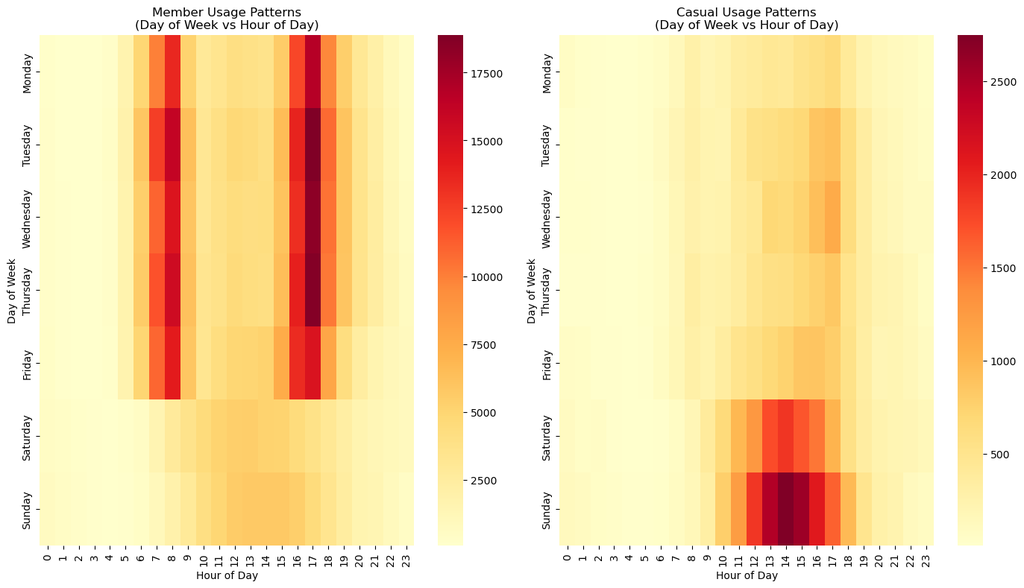

```python
# Usage pattern heatmap
plt.figure(figsize=(14, 8))

# Create separate heatmaps for each user type
for i, usertype in enumerate(['member', 'casual']):
    plt.subplot(1, 2, i+1)

    # Create pivot table for heatmap
    user_data = df_combined[df_combined['usertype'] == usertype]
    heatmap_data = user_data.pivot_table(
        values='trip_id',
        index='day_of_week',
        columns='start_hour',
        aggfunc='count',
        fill_value=0
    )

    # Reorder days
    heatmap_data = heatmap_data.reindex(weekday_order)

    # Create heatmap
    sns.heatmap(heatmap_data, cmap='YlOrRd', annot=False, fmt='d', cbar=True)
    plt.title(f'{usertype.capitalize()} Usage Patterns\n(Day of Week vs Hour of Day)')
    plt.xlabel('Hour of Day')
    plt.ylabel('Day of Week')

plt.tight_layout()
plt.show()
```

```python
# Popular stations analysis
print("=== Popular Stations Analysis ===")

# Top 10 overall popular stations
top_stations = df_combined.groupby('start_station_name').size().sort_values(ascending=False).head(10)
print("\nTop 10 Most Popular Start Stations (Overall):")
for i, (station, count) in enumerate(top_stations.items(), 1):
    print(f"{i:2d}. {station}: {count:,} trips")

# Popular stations by user type
station_by_usertype = df_combined.pivot_table(
    index='start_station_name',
    columns='usertype',
    values='trip_id',
    aggfunc='count',
    fill_value=0
)

# Top 5 stations for each user type
top_member_stations = station_by_usertype.sort_values('member', ascending=False).head(5)
top_casual_stations = station_by_usertype.sort_values('casual', ascending=False).head(5)

print("\nTop 5 Stations for Members:")
for i, (station, row) in enumerate(top_member_stations.iterrows(), 1):
    print(f"{i}. {station}: {row['member']:,} member trips")

print("\nTop 5 Stations for Casual Riders:")
for i, (station, row) in enumerate(top_casual_stations.iterrows(), 1):
    print(f"{i}. {station}: {row['casual']:,} casual trips")
```

```
=== Popular Stations Analysis ===

Top 10 Most Popular Start Stations (Overall):
 1. Canal St & Adams St: 14,151 trips
 2. Clinton St & Washington Blvd: 13,637 trips
 3. Clinton St & Madison St: 13,357 trips
 4. Columbus Dr & Randolph St: 9,079 trips
 5. Kingsbury St & Kinzie St: 9,017 trips
 6. Canal St & Madison St: 8,206 trips
 7. Michigan Ave & Washington St: 7,519 trips
 8. Franklin St & Monroe St: 7,225 trips
 9. Larrabee St & Kingsbury St: 6,707 trips
10. Clinton St & Lake St: 6,671 trips

Top 5 Stations for Members:
1. Canal St & Adams St: 13,797 member trips
2. Clinton St & Washington Blvd: 13,434 member trips
3. Clinton St & Madison St: 12,889 member trips
4. Kingsbury St & Kinzie St: 8,718 member trips
5. Columbus Dr & Randolph St: 8,515 member trips

Top 5 Stations for Casual Riders:
1. Streeter Dr & Grand Ave: 2,741 casual trips
2. Lake Shore Dr & Monroe St: 2,727 casual trips
3. Shedd Aquarium: 1,831 casual trips
4. Millennium Park: 1,403 casual trips
5. Michigan Ave & Oak St: 1,017 casual trips
```

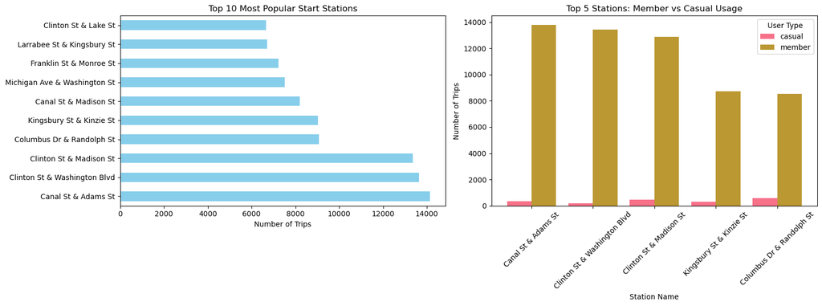

```python
# Visualize top stations
fig, axes = plt.subplots(1, 2, figsize=(16, 6))

# Top 10 overall stations
top_stations.plot(kind='barh', ax=axes[0], color='skyblue')
axes[0].set_title('Top 10 Most Popular Start Stations')
axes[0].set_xlabel('Number of Trips')
axes[0].set_ylabel('')

# Top 5 stations comparison by user type
top_5_comparison = station_by_usertype.sort_values('member', ascending=False).head(5)
top_5_comparison.plot(kind='bar', ax=axes[1], width=0.8)
axes[1].set_title('Top 5 Stations: Member vs Casual Usage')
axes[1].set_xlabel('Station Name')
axes[1].set_ylabel('Number of Trips')
axes[1].tick_params(axis='x', rotation=45)
axes[1].legend(title='User Type')

plt.tight_layout()
plt.show()
```

## 5. Key Findings and Business Insights

```python
# Generate summary statistics for key findings
print("=== KEY FINDINGS SUMMARY ===")
print()

# 1. User composition
member_pct = (user_counts['member'] / user_counts.sum()) * 100
casual_pct = (user_counts['casual'] / user_counts.sum()) * 100
print(f"1. USER COMPOSITION:")
print(f"   • Members: {member_pct:.1f}% ({user_counts['member']:,} trips)")
print(f"   • Casual riders: {casual_pct:.1f}% ({user_counts['casual']:,} trips)")
print()

# 2. Ride length differences
avg_member = df_combined[df_combined['usertype'] == 'member']['ride_length'].mean()
avg_casual = df_combined[df_combined['usertype'] == 'casual']['ride_length'].mean()
difference = ((avg_casual - avg_member) / avg_member) * 100
print(f"2. RIDE LENGTH PATTERNS:")
print(f"   • Average member ride: {avg_member:.1f} minutes")
print(f"   • Average casual ride: {avg_casual:.1f} minutes")
print(f"   • Casual riders take {difference:.0f}% longer rides")
print()

# 3. Peak usage patterns
member_peak_day = weekday_counts[weekday_counts['usertype'] == 'member'].nlargest(1, 'count')['day_of_week'].iloc[0]
casual_peak_day = weekday_counts[weekday_counts['usertype'] == 'casual'].nlargest(1, 'count')['day_of_week'].iloc[0]

member_peak_hour = hourly_counts[hourly_counts['usertype'] == 'member'].nlargest(1, 'count')['start_hour'].iloc[0]
casual_peak_hour = hourly_counts[hourly_counts['usertype'] == 'casual'].nlargest(1, 'count')['start_hour'].iloc[0]

print(f"3. PEAK USAGE PATTERNS:")
print(f"   • Member peak day: {member_peak_day}")
print(f"   • Casual peak day: {casual_peak_day}")
print(f"   • Member peak hour: {member_peak_hour}:00")
print(f"   • Casual peak hour: {casual_peak_hour}:00")
print()

# 4. Weekend vs Weekday usage
weekend_days = ['Saturday', 'Sunday']
weekday_days = ['Monday', 'Tuesday', 'Wednesday', 'Thursday', 'Friday']

member_weekend = df_combined[(df_combined['usertype'] == 'member') &
                           (df_combined['day_of_week'].isin(weekend_days))].shape[0]
member_weekday = df_combined[(df_combined['usertype'] == 'member') &
                           (df_combined['day_of_week'].isin(weekday_days))].shape[0]

casual_weekend = df_combined[(df_combined['usertype'] == 'casual') &
                           (df_combined['day_of_week'].isin(weekend_days))].shape[0]
casual_weekday = df_combined[(df_combined['usertype'] == 'casual') &
                           (df_combined['day_of_week'].isin(weekday_days))].shape[0]

member_weekend_pct = (member_weekend / (member_weekend + member_weekday)) * 100
casual_weekend_pct = (casual_weekend / (casual_weekend + casual_weekday)) * 100

print(f"4. WEEKEND VS WEEKDAY USAGE:")
print(f"   • Members weekend usage: {member_weekend_pct:.1f}%")
print(f"   • Casual weekend usage: {casual_weekend_pct:.1f}%")
print(f"   • Casual riders are {casual_weekend_pct/member_weekend_pct:.1f}x more weekend-oriented")
```

```
=== KEY FINDINGS SUMMARY ===

1. USER COMPOSITION:
   • Members: 91.4% (720,125 trips)
   • Casual riders: 8.6% (67,582 trips)

2. RIDE LENGTH PATTERNS:
   • Average member ride: 11.4 minutes
   • Average casual ride: 38.4 minutes
   • Casual riders take 236% longer rides

3. PEAK USAGE PATTERNS:
   • Member peak day: Tuesday
   • Casual peak day: Sunday
   • Member peak hour: 17:00
   • Casual peak hour: 15:00

4. WEEKEND VS WEEKDAY USAGE:
   • Members weekend usage: 16.6%
   • Casual weekend usage: 47.3%
   • Casual riders are 2.9x more weekend-oriented
```

## 6. Strategic Recommendations

Based on the analysis of Cyclistic bike-share usage patterns, the following strategic recommendations are proposed to convert casual riders into annual members:

### Marketing Strategy Recommendations

- **Insight**: Members predominantly use bikes for weekday commuting (shorter, frequent trips)
- **Action**: Promote the economic benefits of membership for regular commuters
- **Implementation**: "Commuter Challenge" - free trial memberships for frequent casual users

#### 4. **Location-Specific Marketing**

- **Insight**: Different user types favor different station locations
- **Action**: Deploy targeted advertising at high-casual-usage stations
- **Implementation**: Digital displays and QR codes at top casual rider stations

### Next Steps

1. **A/B Testing**: Pilot test marketing campaigns with control groups
2. **Customer Surveys**: Gather direct feedback from casual riders about barriers to membership
3. **Seasonal Analysis**: Extend analysis to full year data for seasonal patterns
4. **Pricing Strategy**: Evaluate flexible pricing options (monthly, seasonal memberships)

```python
# Save cleaned dataset for future analysis
print("=== Saving Final Dataset ===")
output_filename = 'cyclistic_cleaned_data.csv'
df_combined.to_csv(output_filename, index=False)
print(f"Cleaned dataset saved as: {output_filename}")
print(f"Final dataset contains {len(df_combined):,} trips from {df_combined['start_time'].min().date()} to {df_combined['start_time'].max().date()}")
print("\nAnalysis completed successfully!")
```

```
=== Saving Final Dataset ===
Cleaned dataset saved as: cyclistic_cleaned_data.csv
Final dataset contains 787,707 trips from 2019-01-01 to 2020-03-31

Analysis completed successfully!
```